# Analisis de Procesos de Compra

La siguiente presentacion tiene por objetivo mostrar de manera preliminar los resultados más llamativos o relevantes de los procesos de compra, un con enfoque especial en los resultados de la muestra de licitaciones realizada por el equipo.

# Universo Muestral

- Se consideraron todos los procesos de licitacion desde el 1 de enero de 2017 hasta el 31 de diciembre del 2019 ambas fechas inclusive.
- Adicionalmente, se cruzó esta base con las ordenes de compra efectuadas durante el mismo periodo, descartando aquellas licitaciones que no hayan registrado ordenes de compra en el periodo.

A continuación se presentan algunos datos del universo muestral.

## Totales

- El tamaño del universo es de 2.3 millones de licitaciones que posteriormente registraron alguna compra.
- En terminos de montos, la base esta bastante "sucia", por lo que se presenta en su lugar el monto total de las ordenes de compra de estas licitacione, que corresponde a 9.77 billones de pesos.
- En termino de transacciones, las ordenes de compra representan un total de 4.6 millones de compras.
- El promedio de líneas por licitación es de 5.44

## Participantes

- Se presentan en primer lugar el numero de licitaciones por institución:

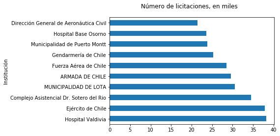

- El panorama cambia cuando se considera el numero de órdenes de compra por institucion.

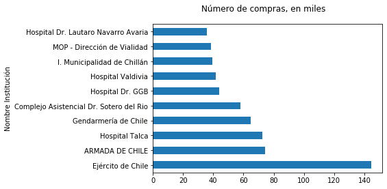

## Montos

- A continuación se presentan los montos transados por institución de acuerdo a las ordenes de compra que surgieron de las licitaciones del universo.

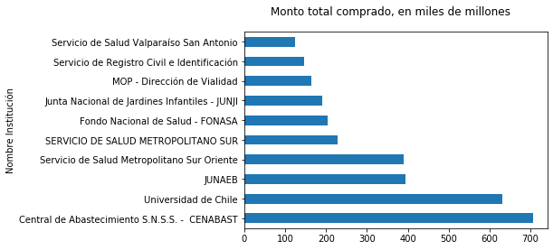

- Por otro lado los montos vendidos por proveedor se presentan a continuación.

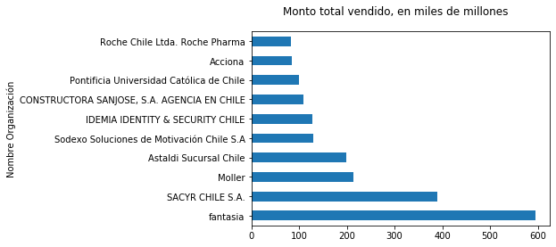

Fantasía es una empresa del rubro de jardines infantiles y sala cunas.

- Finalmente se presentan las ventas por codigo ONU del producto. Notar que el segundo item más vendido es Jardines infantines o sala cunas

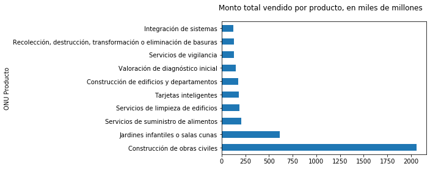

# Muestreo

Se realizó un muestreo aleratorio simple de tamaño N=400, dado que esta cantidad permite determinar con un 95 por ciento de confianza hipotesis del estilo sí o no, sin tener que preocuparnos de la varianza real.

# Datos Generales de la Muestra

A continuación se presentan algunos datos de la muestra *antes* de la revision manual.

## Montos

- A continuación se presentan los montos transados por los productos licitados en ordenes de compra generadas por las licitaciones de la muestra.

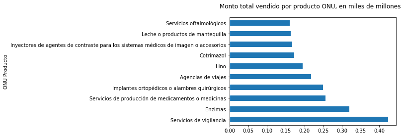

- Los principales proveedores de estas ordenes de compras:

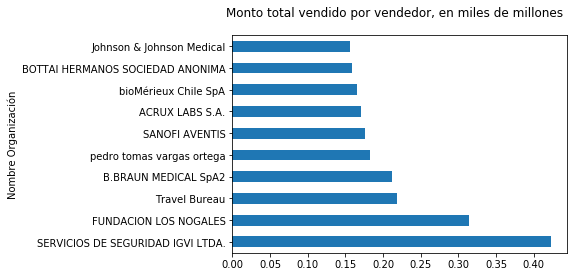

- Finalmente se presenta el monto comprado por institucion de acuerdo a las licitaciones de la muestra.

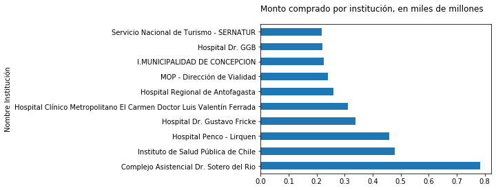

- Finalmente, el número promedio de lineas por licitación de la muestra es de 54.9

# Rendimiento

## Licitaciones

Se observar de acuerdo a la muestra el rendimiento de las licitaciones seleccionadas.

Estos datos fueron actualizados unos minutos antes de la presentación.

En primer lugar se tiene el numero de participantes: **5.22**

Ratio 1-2 promedio es de **0.8**, con una desviación estándar de **0.18**

## Distribucion de oferentes

A continuación se presenta la distribucipon del numero de oferentes por licitacion de acuerdo a la muestra.

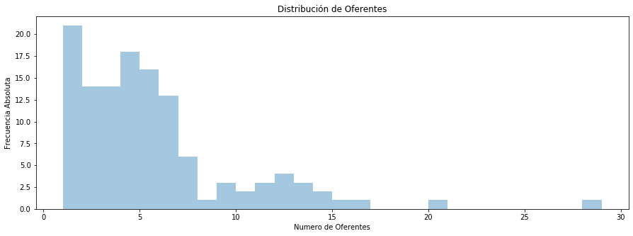

## Precios de Referencia

Al analizar aquellas licitaciones que tenian precio de referencia, se observa que en un bajo porcentaje (menos del **5%**) estos corresponden a la oferta ganadora. Por otro lado, se observa que en un **34%** de los casos el precio ganador es mejor que el precio de referencia (se descartaron los casos en que el precio ganador era menos de un 10% del precio de referencia por considerarse que probablemente en este caso el precio de referencia era para toda la compra)

## Toma de Razón

Hasta el momento no se tienen casos que hayan requerido toma de razon por parte de la contraloría.

## Limitantes a la Competencia

Del total de 166 licitaciones revisadas, un **30%** presentó, a juicio del equipo, alguna limitante a la competencia. Una vez que se estandarizen las razones principales, se puede presentar en detalle cuales son las principales razones de estas limitantes.

## Consistencia Digital

De los casos analizados se tiene que cerca de un **40%** presenta alguna inconsistencia al pasar a formato digital, esto se considera una cantidad muy alta.